# Time Series Analysis 1

```r
set.seed(330)
X<-rnorm(75 , 1,sqrt(3))
a<-exp(X)
a
```

```
##  [1]  39.94886445  48.53328841   3.80685807   7.29059679   7.42300623
##  [6]   2.05309848   0.13942052   1.66304375   6.25948435   0.53417057
## [11]  10.22905564   0.53733378   2.22447120   7.01111848   3.69324872
## [16]   1.77352787  20.21423740   3.05130680   0.44227301   2.30510843
## [21]  16.39741650   3.35320433   1.26796330   3.76260856   0.51432439
## [26] 242.65832419   0.75219019   6.28607594   1.37456366   0.01620074
## [31]  14.97541375   1.16607242   1.09368928   0.64237275  11.30746831
## [36]   4.00306731   2.05281173   0.38857928   1.39049643   2.43003746
## [41]   1.10494871   0.16980578   7.19511597  94.80008024   0.38239211
## [46]   3.75212875   4.04007951   2.26637871  38.29428944   0.40759216
## [51]   0.14244307  35.44785070   0.41873928   1.49639162   1.32962591
## [56]   1.33901085   6.31483046   0.40833016   1.47585811   1.55955944
## [61]   3.79880623   3.74467754   2.02087650   0.43843957   6.47627150
## [66]  12.04415867  26.73233614   3.66741089   0.49595308   0.81932193
## [71]   1.36958800   3.75258056   5.92838269   0.46849984   0.29690894
```

```r
mean(a)
```

```
## [1] 10.12488
```

```r
t.test(a,conf.level = 0.95)
```

```
##
##  One Sample t-test
##
## data:  a
## t = 2.8615, df = 74, p-value = 0.005479
## alternative hypothesis: true mean is not equal to 0
## 95 percent confidence interval:
##   3.074564 17.175197
## sample estimates:
## mean of x
##  10.12488
```

```r
getwd()
```

```
## [1] "C:/Users/Sinan/Desktop"
```

```r
setwd("C:/Users/Sinan/Desktop")
cardata <- read.table(file="cars.txt", header=TRUE)
head(cardata,n=10)
```

```
##    speed  dist
## 1      8  3.50
## 2      8 17.50
## 3     14  7.00
## 4     14 38.50
## 5     16 28.00
## 6     18 17.50
## 7     20 31.50
## 8     20 45.50
## 9     20 59.50
## 10    22 29.75
```

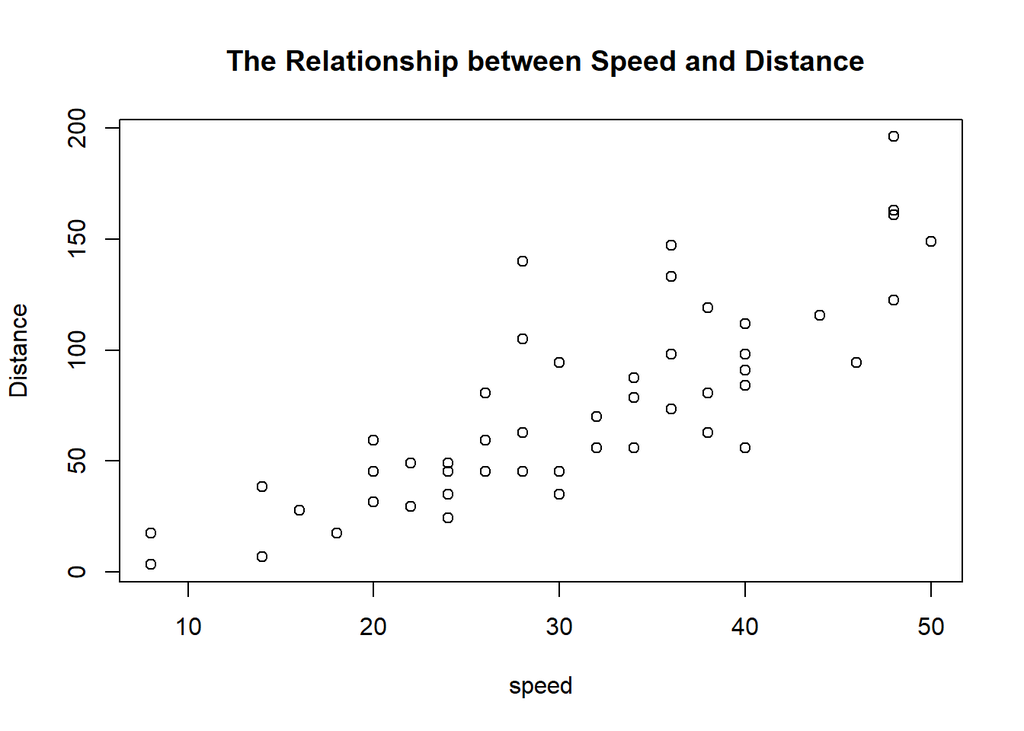

```r
plot(cardata,xlab="speed",ylab="Distance",main=" The Relationship between Speed and Distance")
```

```r
cor(cardata$speed,cardata$dist)
```

```
## [1] 0.8124657
```

#### The correlation shows us that there is high relationship between two data.This means that when one data is increasing then the other one will increase as nearly with the same rate.

```r
getwd()
```

```
## [1] "C:/Users/Sinan/Desktop"
```

```r
setwd("C:/Users/Sinan/Desktop")
netdata <- read.table(file="electricity.txt", header=FALSE)
head(netdata,n=10)
```

```
##      V1
## 1  1254
## 2  1290
## 3  1379
## 4  1346
## 5  1535
## 6  1555
## 7  1655
## 8  1651
## 9  1500
## 10 1538
```

```r
netdatats<-ts(netdata,frequency = 12,start=c(1956,1))
netdatats
```

```
##       Jan  Feb  Mar  Apr  May  Jun  Jul  Aug  Sep  Oct  Nov  Dec
## 1956 1254 1290 1379 1346 1535 1555 1655 1651 1500 1538 1486 1394
## 1957 1409 1387 1543 1502 1693 1616 1841 1787 1631 1649 1586 1400
## 1958 1497 1463 1648 1595 1777 1824 1994 1835 1787 1699 1633 1645
## 1959 1597 1577 1709 1756 1936 2052 2105 2016 1914 1925 1824 1765
## 1960 1721 1752 1914 1857 2159 2195 2287 2276 2096 2055 2004 1924
## 1961 1851 1839 2019 1937 2270 2251 2382 2364 2129 2110 2072 1980
## 1962 1995 1932 2171 2162 2489 2424 2641 2630 2324 2412 2284 2186
## 1963 2184 2144 2379 2383 2717 2774 3051 2891 2613 2600 2493 2410
## 1964 2390 2463 2616 2734 2970 3125 3342 3207 2964 2919 2764 2732
```

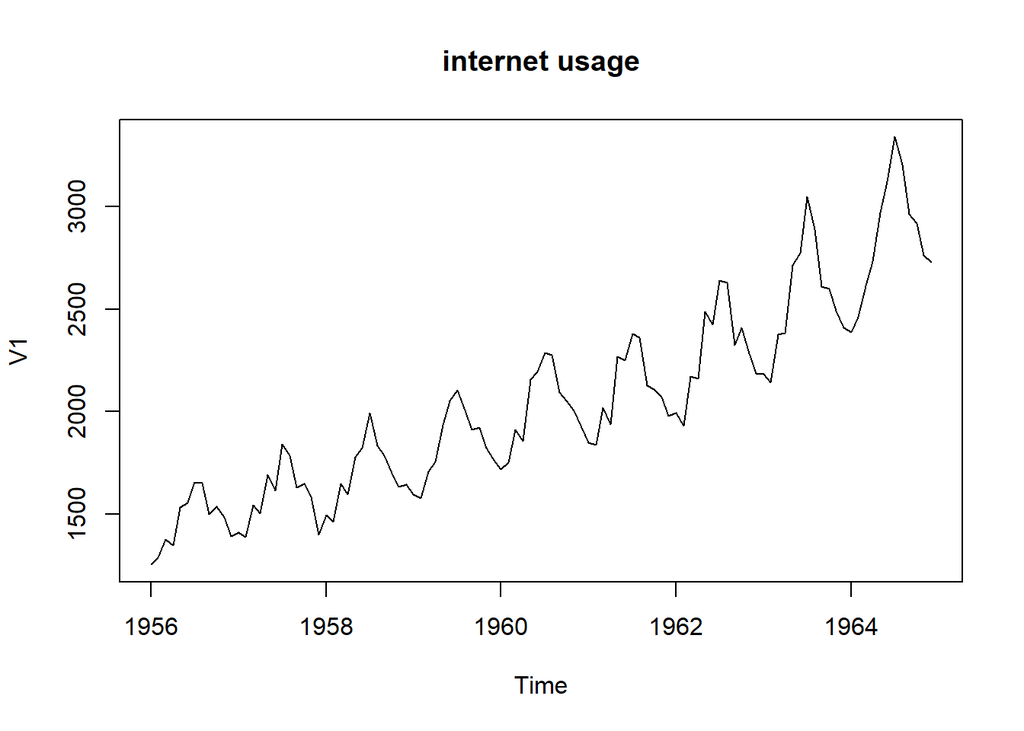

```r
plot(netdatats, main="internet usage")
```

#### , it can be seen that there are seasonality and an increasing trend between years 1956 and 1965.Also,variance is small in the first years according to the last years, that is,variance is increasing by time.Because of this reason, data shows us that it changes multiplicatively.

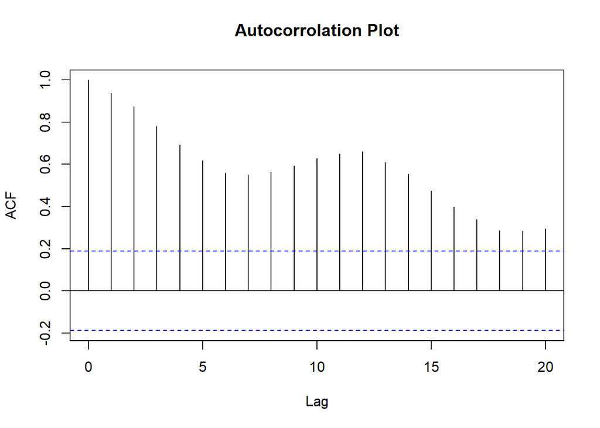

```r
acf(netdata,main="Autocorrolation Plot")
```

#### ACF is decreasing very slowly and remains well above the significance range (dotted blue lines). This is indicative of a non-stationary series and an indicative of sufficiently high correlation.

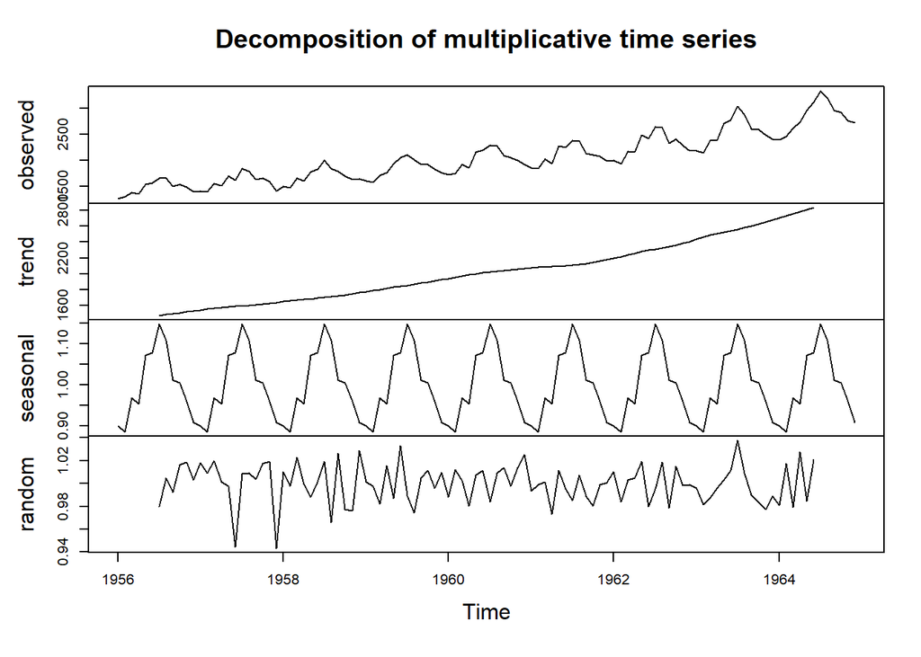

```r
netdatats_dec<-decompose(netdatats,type = "multiplicative")
plot(netdatats_dec)
```

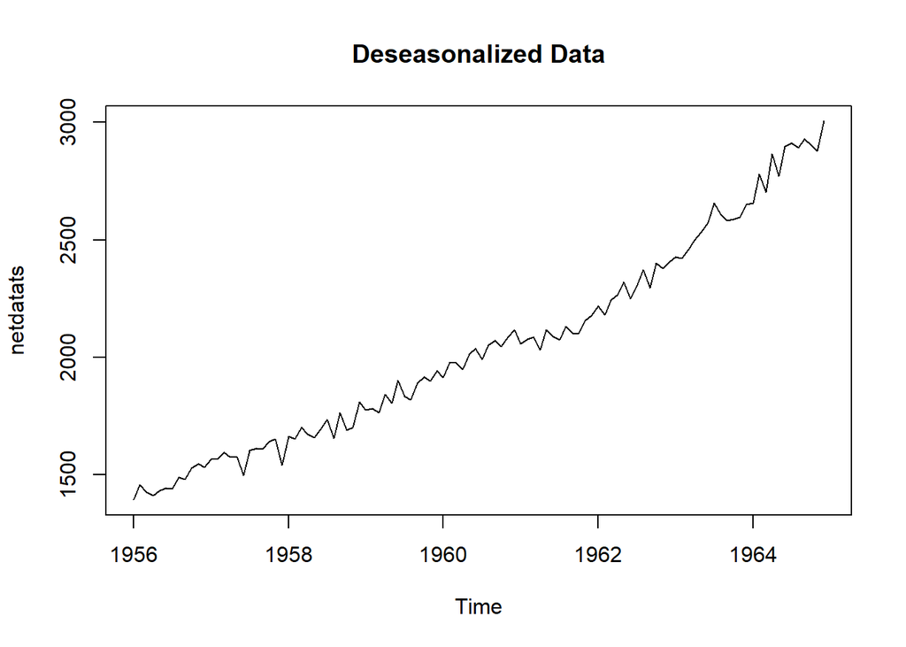

```r
desea_data<-netdatats/netdatats_dec$seasonal
plot(desea_data, main="Deseasonalized Data")
```

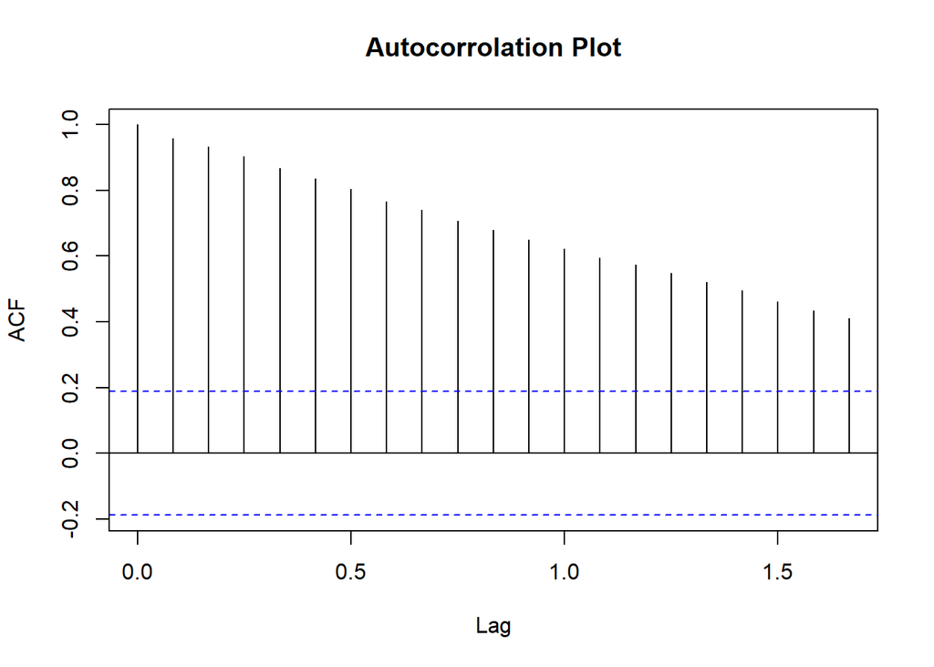

```r
acf(desea_data,main="Autocorrolation Plot")
```

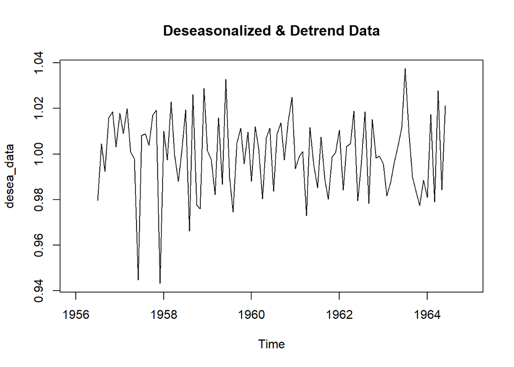

```r
detrend_and_desea_data<-desea_data/netdatats_dec$trend
plot(detrend_and_desea_data,main="Deseasonalized & Detrend Data")
```

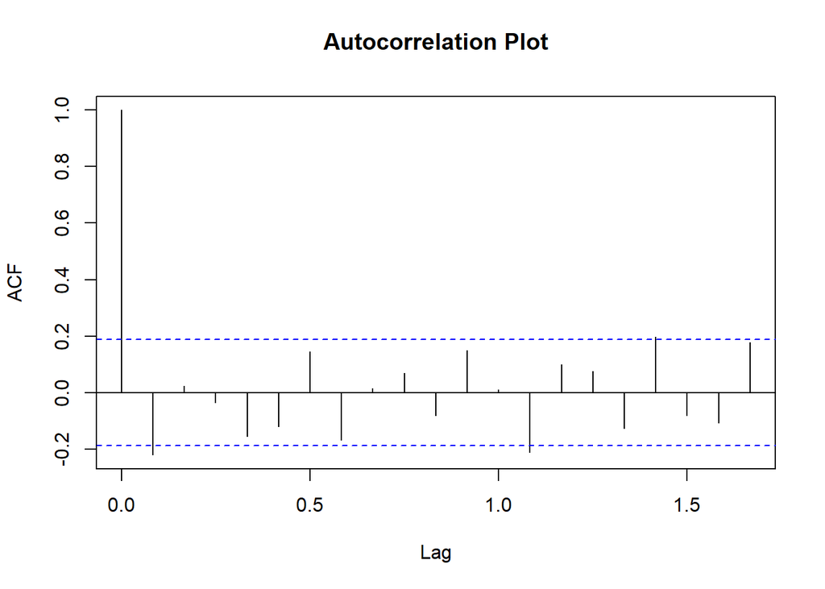

```r
acf(detrend_and_desea_data,na.action=na.pass,main="Autocorrelation Plot")
```